# Assess single molecule rates of occupancy

Melanie (1028-02098-001-001)

March 18, 2026

# Introduction

The goal of this document is to recapitulate (realign and reprocess) the data from 2020 Soenmezer et al.(https://www.cell.com/molecular-cell/fulltext/S1097-2765(20)30793-0#mmc1).

# Computational Setup

```r
#Standard packages
library(rtracklayer) ; library(GenomicRanges); library(magrittr) ; library(Biostrings)
library(ggplot2) ; library(reshape2); library(plyranges); library(Rsamtools); library(parallel)
library(dplyr); library(data.table); library(patchwork); library(readr); library(testit)

#KNITR Options
setwd("/n/projects/mw2098/publications/2024_weilert_acc/code/2_analysis/")
figure_filepath<-"figures/17_smf_analysis"
options(knitr.figure_dir=figure_filepath, java.parameters = "- Xmx6g")

#Lab sources
source("scripts/r/granges_common.r")
source("scripts/r/metapeak_common.r")
source("scripts/r/knitr_common.r")
source("scripts/r/caching.r")
source("scripts/r/metapeak_functions.r")

#Specific sources
library(BSgenome.Mmusculus.UCSC.mm10)
library(TxDb.Mmusculus.UCSC.mm10.knownGene)
library(ggseqlogo)
source("scripts/r/motif_functions.r")

#Pre-existing variables
bsgenome<-BSgenome.Mmusculus.UCSC.mm10
txdb<-TxDb.Mmusculus.UCSC.mm10.knownGene
regions.path<-'tsv/mapped_motifs/all_islands_curated_1based_w_experimental_data.tsv.gz'
motifs.path<-'tsv/mapped_motifs/all_instances_curated_0based_w_perturb.tsv.gz'
pairs.path<-'tsv/mapped_motifs/all_pairs_curated_0based_with_cooperativity.tsv.gz'
```

# Import paired motifs

```r
pairs.df<-readr::read_tsv(pairs.path)
motifs.df<-readr::read_tsv(motifs.path)
```

# Pull in SMF data

## Pull raw data

Generate a `wget` script from https://www.ebi.ac.uk/ena/browser/view/PRJEB38395.

- ERR4165153: mESC replicate 1 SMF
- ERR4165147: mESC replicate 2 SMF

```bash
cd /n/projects/mw2098/publications/2024_weilert_acc/public/published/Sonmezer_2021_et_al/data/fastq
sbatch ena-file-download-selected-files-20241119-1957_sbatch.sh
```

## Modify code repository to match filepaths

The code found at https://github.com/Krebslabrep/Soenmezer_2020_SMF provides scripts to align (bowtie1) and process (QuasR) SMF data. We pulled this down:

```bash
cd /n/projects/mw2098/publications/2024_weilert_acc/public/published/Sonmezer_2021_et_al/code
git clone https://github.com/Krebslabrep/Soenmezer_2020_SMF
```

And modified the files inside this repository to match our expected filepaths. We also needed to install some specific packages:

```r
ml R #load R
R #launch R
BiocManager::install('QuasR')
BiocManager::install('pheatmap')
# BiocManager::install('BSgenome')
# BiocManager::install('BSgenome.Mmusculus.UCSC.mm10')
# BiocManager::install('viridis')
```

# Leverage processed SMF data

At the following link (https://www.ebi.ac.uk/biostudies/arrayexpress/studies/E-MTAB-9123) we pulled classified states from the paper. Given the sites of interest, we want to process them in understandable terms.

First define classes that the TFBS states can exist in.

```r
state_classes.list<-list(
  'published' = list(bound = '101', unbound = '111', nucleosome = c('000', '001', '011', '100', '110')),
  'strict' = list(bound = '101', unbound = '111', nucleosome = c('000'))
)
```

Import the data. Configuration `NO` means nucleosome occupied. Configuration `DE` means the mutant, so we will ignore those.

```r
smf.list<-list(
  single  = readRDS('/n/projects/mw2098/publications/2024_weilert_acc/public/published/Sonmezer_2021_et_al/data/rds/E-MTAB-9123/SingleTFSorting_NO.rds'),
  cluster = readRDS('/n/projects/mw2098/publications/2024_weilert_acc/public/published/Sonmezer_2021_et_al/data/rds/E-MTAB-9123/TFClusterSorting_NO.rds')
)
```

## Single

Collect information from the different SMF configurations. First we will do the isolated TFs.

```r
#Collect coordinates
smf_single_coords.df<-smf.list$single[[1]] %>% as.data.frame
smf_single_coords.df$TFBS_cluster<-names(smf.list$single[[1]])

#Collect read counts  at sufficiently enriched regions
smf_single_counts.df<-smf.list$single[[3]] %>% dplyr::filter(Sample == 'SMF_MM_ES_NO_R_NextSeq', !is.na(Sample), !is.na(Counts)) %>%
  dplyr::select(State, Counts, TFBS_cluster) %>%
  dplyr::group_by(TFBS_cluster) %>%
  dplyr::mutate(TotalCounts = sum(Counts)) %>%
  dplyr::filter(!is.na(TotalCounts)) %>%
  tidyr::pivot_wider(names_from = 'State', values_from = Counts) %>%
  dplyr::mutate(percent_open_published = (`101` + `111`)/TotalCounts,
                percent_open_strict = 1-((`000`)/TotalCounts))

#Merge data together
smf_single_all.df<-dplyr::left_join(smf_single_coords.df, smf_single_counts.df) %>% dplyr::filter(!is.na(TotalCounts)) %>%
  makeGRangesFromDataFrame(., keep.extra.columns = T, starts.in.df.are.0based = F) %>%
  plyranges::mutate(acc_reads = regionSums(GenomicRanges::resize(., width = 1000, fix = 'center'), 'bw/mesc_native_atac_cutsites_combined.bw'),
                    island_seq = getSeq(bsgenome, GenomicRanges::resize(., width = 1000, fix = 'center'), as.character = T),
                    C = stringr::str_count(island_seq, 'C'),
                    G = stringr::str_count(island_seq, 'G'),
                    CpG = stringr::str_count(island_seq, 'CG'),
                    CpG_ratio = round((CpG) / ((((C + G) / 2) ^ 2) / 1000), 2)) %>%
  as.data.frame()
```

Match the single TF smf data with our motif information.

```r
motifs_w_coop.gr<-motifs.df %>%
  dplyr::filter(motif %in% c('Oct4-Sox2','Sox2','Klf4')) %>%
  dplyr::left_join(.,
                   pairs.df %>%
                     dplyr::filter(motif_pair_distance<=200) %>% #require pairs to be nuc-range
                     dplyr::group_by(motif_id.x) %>%
                     dplyr::summarize(med_add_acc_coop = median(add_acc_coop)) %>%
                     dplyr::filter(abs(med_add_acc_coop)<50) %>% #filter out weird outliers
                     dplyr::rename(motif_id = motif_id.x)) %>%
  makeGRangesFromDataFrame(keep.extra.columns = T, starts.in.df.are.0based = T, seqnames.field = 'seqnames', start.field = 'start', end.field = 'end')

#Find overlaps between SMF features and motifs
single.ov<-findOverlaps(makeGRangesFromDataFrame(smf_single_all.df, keep.extra.columns = T), motifs_w_coop.gr, ignore.strand = T)
smf_single_all.df$ov_motif<-'none'
smf_single_all.df$ov_coop<-NA
smf_single_all.df$ov_motif[single.ov@from]<-motifs_w_coop.gr$motif[single.ov@to]
smf_single_all.df$ov_coop[single.ov@from]<-motifs_w_coop.gr$med_add_acc_coop[single.ov@to]

smf_single_all.df$ov_motif %>% table
```

```
## .
##      Klf4      none Oct4-Sox2      Sox2
##      3369     42177      1965       833
```

```r
smf_single_all.df$ov_coop %>% summary
```

```
##    Min. 1st Qu.  Median    Mean 3rd Qu.    Max.    NA's
##  -44.07    0.94    1.07    1.10    1.24   31.64   43076
```

```r
smf_single_all.df$has_Btbd11<-overlapsAny(makeGRangesFromDataFrame(smf_single_all.df, keep.extra.columns = T), GRanges('chr10', IRanges(85538671, 85540703)))
```

Compare relationship between acc. and openness.

```r
single_tf_p_vs_acc.plot<-smf_single_all.df %>% tidyr::pivot_longer(cols = c(percent_open_published, percent_open_strict), names_to = 'criteria', values_to = 'p_open') %>%
  ggplot(., aes(x = p_open, y = log(acc_reads)))+
  ggrastr::geom_point_rast(color = 'gray', size = .1)+
  ggrastr::geom_point_rast(data = . %>% dplyr::filter(!is.na(ov_coop)), color = 'black', size = .1)+
  ggrastr::geom_point_rast(data = . %>% dplyr::filter(has_Btbd11), color = 'red', size = 1)+
  ggpubr::stat_cor(method = 'spearman', label.x.npc = 'left', label.y.npc = 'top')+
  facet_grid(. ~ criteria)+
  ggtitle('TF Single SMF results', subtitle = 'p_open vs acc')+
  theme_classic()

single_tf_p_vs_coop.plot<- smf_single_all.df %>% tidyr::pivot_longer(cols = c(percent_open_published, percent_open_strict), names_to = 'criteria', values_to = 'p_open') %>%
  dplyr::mutate(p_open_grouped = plyr::round_any(p_open, .05, f = ceiling)) %>%
  ggplot(., aes(x = p_open_grouped, y = log(ov_coop), group = p_open_grouped))+
  geom_hline(yintercept = 0, linetype = 'dashed')+
  geom_boxplot()+
  # ggrastr::geom_point_rast(aes(color = ov_motif), size = .1)+
  ggpubr::stat_cor(method = 'spearman', label.x.npc = 'left', label.y.npc = 'top')+
  facet_grid(ov_motif ~ criteria)+
      scale_y_continuous(limits = c(-.5, .5))+
  # scale_color_gradient2(high = '#b2182b', mid = 'black', low = '#2166ac', midpoint = 0, name = 'Med. log. coop') +
  ggtitle('TF Single SMF results', subtitle = 'p_open vs coop')+
  theme_classic()

single_tf.plot<-single_tf_p_vs_acc.plot + single_tf_p_vs_coop.plot + plot_layout(ncol = 1, heights = c(1, 3))
ggsave(paste0(figure_filepath, '/smf_single_tf_summary.png'), single_tf.plot, height = 10, width = 8)
ggsave(paste0(figure_filepath, '/smf_single_tf_summary.pdf'), single_tf.plot, height = 10, width = 8)
```

Report generalized summary statistics of openness at these regions.

```r
smf_single_all.df$percent_open_published %>% summary()
```

```
##    Min. 1st Qu.  Median    Mean 3rd Qu.    Max.    NA's
##   0.000   0.128   0.252   0.339   0.517   1.000   12903
```

```r
sd(smf_single_all.df$percent_open_published, na.rm = T)
```

```
## [1] 0.2589757
```

Plot without log-space accessibility reads.

```r
single_tf_p_vs_acc.plot<-smf_single_all.df %>% tidyr::pivot_longer(cols = c(percent_open_published, percent_open_strict), names_to = 'criteria', values_to = 'p_open') %>%
  ggplot(., aes(x = p_open, y = acc_reads))+
  ggrastr::geom_point_rast(color = 'gray', size = .1)+
  ggrastr::geom_point_rast(data = . %>% dplyr::filter(!is.na(ov_coop)), color = 'black', size = .1)+
  ggpubr::stat_cor(method = 'spearman', label.x.npc = 'left', label.y.npc = 'top')+
  facet_grid(criteria ~ .)+
  scale_y_continuous(limits = c(0, 20000))+
  ggtitle('TF Single SMF results', subtitle = 'p_open vs acc')+
  theme_classic()
ggsave(paste0(figure_filepath, '/smf_single_tf_summary_linear.png'), single_tf_p_vs_acc.plot, height = 6, width = 8)
ggsave(paste0(figure_filepath, '/smf_single_tf_summary_linear.pdf'), single_tf_p_vs_acc.plot, height = 6, width = 8)
```

```r
single_tf_p_vs_acc.plot<-smf_single_all.df %>% tidyr::pivot_longer(cols = c(percent_open_published, percent_open_strict), names_to = 'criteria', values_to = 'p_open') %>%
  ggplot(., aes(x = log(p_open+1), y = log(acc_reads)))+
  ggrastr::geom_point_rast(color = 'gray', size = .1)+
  ggrastr::geom_point_rast(data = . %>% dplyr::filter(!is.na(ov_coop)), color = 'black', size = .1)+
  ggpubr::stat_cor(method = 'spearman', label.x.npc = 'left', label.y.npc = 'top')+
  facet_wrap(~criteria, scales = 'free')+
  ggtitle('TF Single SMF results', subtitle = 'p_open vs acc')+
  theme_classic()
ggsave(paste0(figure_filepath, '/smf_single_tf_summary_log_both.png'), single_tf_p_vs_acc.plot, height = 3, width = 5)
ggsave(paste0(figure_filepath, '/smf_single_tf_summary_log_both.pdf'), single_tf_p_vs_acc.plot, height = 3, width = 5)
```

Check whether data fits better in linear or log model.

```r
linear_rsq <- function(x, y) summary(lm(y~x))$r.squared
logy_rsq <- function(x, y) summary(lm(log(y)~x))$r.squared
logxy_rsq <- function(x, y) summary(lm(log(y)~log(x)))$r.squared
logxy_p1_rsq <- function(x, y) summary(lm(log(y)~log(x+1)))$r.squared


df<-lapply(c('percent_open_published', 'percent_open_strict'), function(y){
  smf_single_all.df$y<-smf_single_all.df[[y]]
  smf_single_filt.df<-smf_single_all.df %>% dplyr::filter(y != 0)

  rsq.df<-rbind(
    data.frame(metric = y,
               linear_rsq = linear_rsq(x = smf_single_all.df[[y]], y = smf_single_all.df$acc_reads) %>% round(., 2),
               logy_rsq = logy_rsq(x = smf_single_all.df[[y]], y = smf_single_all.df$acc_reads) %>% round(., 2),
               logxy_rsq = logxy_rsq(x = smf_single_filt.df$y, y = smf_single_filt.df$acc_reads) %>% round(., 2),
               mode = 'all'),
    data.frame(metric = y,
               linear_rsq = linear_rsq(x = smf_single_all.df %>% dplyr::filter(ov_motif != 'none') %>% .[[y]],
                                       y = smf_single_all.df %>% dplyr::filter(ov_motif != 'none') %>% .$acc_reads) %>% round(., 2),
               logy_rsq = logy_rsq(x = smf_single_all.df %>% dplyr::filter(ov_motif != 'none') %>% .[[y]],
                                   y = smf_single_all.df %>% dplyr::filter(ov_motif != 'none') %>% .$acc_reads) %>% round(., 2),
               logxy_rsq = logxy_rsq(x = smf_single_filt.df %>% dplyr::filter(ov_motif != 'none') %>% .[[y]],
                                     y = smf_single_filt.df %>% dplyr::filter(ov_motif != 'none') %>% .$acc_reads) %>% round(., 2),
              mode = 'motifs')
  )

  return(rsq.df)
}) %>% rbindlist()

df
```

```
##                    metric linear_rsq logy_rsq logxy_rsq   mode
##                    <char>      <num>    <num>     <num> <char>
## 1: percent_open_published       0.07     0.10      0.13    all
## 2: percent_open_published       0.17     0.21      0.21 motifs
## 3:    percent_open_strict       0.08     0.14      0.13    all
## 4:    percent_open_strict       0.12     0.17      0.15 motifs
```

```r
smf_single_all.df %>%
  dplyr::group_by(ov_motif) %>%
  dplyr::summarize(linear_rsq = linear_rsq(percent_open_published, acc_reads),
                   logy_rsq = logy_rsq(percent_open_published, acc_reads),
                logxy_p1_rsq = logxy_p1_rsq(percent_open_published, acc_reads))
```

```
## # A tibble: 4 × 4
##   ov_motif  linear_rsq logy_rsq logxy_p1_rsq
##   <chr>          <dbl>    <dbl>        <dbl>
## 1 Klf4          0.157    0.221        0.224
## 2 Oct4-Sox2     0.190    0.222        0.225
## 3 Sox2          0.164    0.172        0.175
## 4 none          0.0455   0.0792       0.0883
```

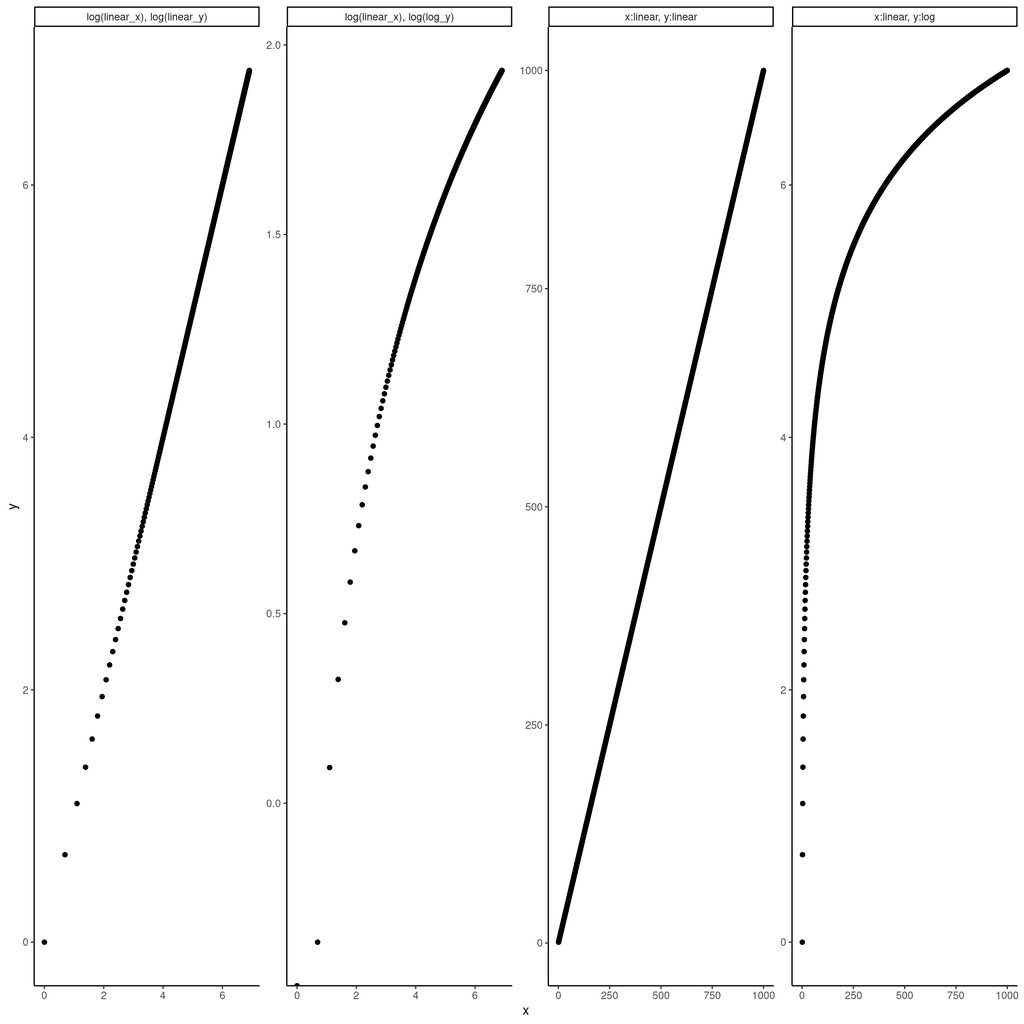

```r
max_val<-1000
data.frame(x = c(rep(1:max_val, 2), log(1:max_val), log(1:max_val)),
           y = c(1:max_val, log(1:max_val), log(1:max_val), log(log(1:max_val))),
           state = c(rep('x:linear, y:linear', max_val), rep('x:linear, y:log', max_val), rep('log(linear_x), log(linear_y)', max_val), rep('log(linear_x), log(log_y)', max_val))) %>%
  ggplot(., aes(x = x, y = y))+
  geom_point()+
  facet_wrap(~state, scales = 'free', nrow = 1)+
  theme_classic()
```

## Cluster

```r
#Collect coordinates
smf_cluster_coords.df<-smf.list$cluster[[1]]$ClusterCoordinates %>% as.data.frame
smf_cluster_coords.df$TFBS_cluster<-names(smf.list$cluster[[1]]$ClusterCoordinates)

smf_cluster_coords.df$width %>% summary
```

```
##    Min. 1st Qu.  Median    Mean 3rd Qu.    Max.
##   24.00   42.00   59.00   64.82   78.00  359.00
```

```r
#Collect read counts  at sufficiently enriched regions
smf_cluster_counts.df<-smf.list$cluster[[3]] %>% dplyr::filter(Sample == 'SMF_MM_ES_NO_R_NextSeq', !is.na(Sample), !is.na(Counts)) %>%
  dplyr::select(State, Counts, TFBS_cluster) %>%
  dplyr::left_join(., smf_cluster_coords.df %>% dplyr::select(TFBS_cluster, width)) %>%
  dplyr::group_by(TFBS_cluster) %>%
  dplyr::mutate(TotalCounts = sum(Counts),
                StateOcc0 = stringr::str_count(State, '0'),
                StateOccTotal = nchar(State),
                StateOccRate = StateOcc0/StateOccTotal) %>%
  dplyr::group_by(TFBS_cluster) %>%
  dplyr::summarize(total_counts = TotalCounts %>% unique,
                   counts_closed_strict = sum(ifelse(StateOcc0==StateOccTotal, Counts, 0)),
                   counts_closed_75 = sum(ifelse(StateOcc0>=.75*StateOccTotal, Counts, 0))) %>%
  dplyr::mutate(percent_open_lenient = 1-(counts_closed_75/total_counts),
                percent_open_strict = 1-(counts_closed_strict/total_counts))

#Merge data together
smf_cluster_all.df<-dplyr::left_join(smf_cluster_coords.df, smf_cluster_counts.df) %>% dplyr::filter(!is.na(total_counts)) %>%
  makeGRangesFromDataFrame(., keep.extra.columns = T, starts.in.df.are.0based = F) %>%
  plyranges::mutate(acc_reads = regionSums(GenomicRanges::resize(., width = 1000, fix = 'center'), 'bw/mesc_native_atac_cutsites_combined.bw'),
                    island_seq = getSeq(bsgenome, GenomicRanges::resize(., width = 1000, fix = 'center'), as.character = T),
                    C = stringr::str_count(island_seq, 'C'),
                    G = stringr::str_count(island_seq, 'G'),
                    CpG = stringr::str_count(island_seq, 'CG'),
                    CpG_ratio = round((CpG) / ((((C + G) / 2) ^ 2) / 1000), 2)) %>%
  as.data.frame()

smf_cluster_all.df$has_Btbd11<-overlapsAny(makeGRangesFromDataFrame(smf_cluster_all.df, keep.extra.columns = T), GRanges('chr10', IRanges(85538671, 85540703)))
```

Match motif information with the clustered SMF data.

```r
#Find overlaps between SMF features and motifs
cluster.ov<-findOverlaps(motifs_w_coop.gr, makeGRangesFromDataFrame(smf_cluster_all.df, keep.extra.columns = T), ignore.strand = T)

#Mark overlaps with cluster
smf_cluster_all.df$ov_motif<-'none'
smf_cluster_all.df$ov_motif[cluster.ov@to %>% unique]<-'ov'
smf_cluster_all.df$ov_motif %>% table
```

```
## .
## none   ov
## 1542  501
```

```r
#Mark overlaps w motifs
motifs_w_coop.gr$TFBS_cluster<-'none'
motifs_w_coop.gr$TFBS_cluster[cluster.ov@from]<-smf_cluster_all.df$TFBS_cluster[cluster.ov@to]

motifs_w_cluster.df<-motifs_w_coop.gr %>%
  as.data.frame %>%
  dplyr::left_join(., smf_cluster_all.df %>% dplyr::select(TFBS_cluster, percent_open_lenient, percent_open_strict, acc_reads))
```

Compare relationship between acc. and openness.

```r
cluster_tf_p_vs_acc.plot<-smf_cluster_all.df %>% tidyr::pivot_longer(cols = c(percent_open_lenient, percent_open_strict), names_to = 'criteria', values_to = 'p_open') %>%
  # dplyr::group_by(TFBS_cluster) %>%
  # dplyr::summarize(p_open = median(p_open), acc_reads = median(acc_reads)) %>%
  ggplot(., aes(x = p_open, y = log(acc_reads)))+
  ggrastr::geom_point_rast(data = . %>% dplyr::filter(ov_motif=='none'), color = 'gray', size = .1)+
  ggrastr::geom_point_rast(data = . %>% dplyr::filter(ov_motif=='ov'), color = 'red', size = .1)+
  ggpubr::stat_cor(method = 'spearman', label.x.npc = 'left', label.y.npc = 'top')+
  facet_grid(. ~ criteria)+
  ggtitle('TF cluster SMF results', subtitle = 'p_open vs acc')+
  theme_classic()

cluster_tf_p_vs_coop.plot<- motifs_w_cluster.df %>% tidyr::pivot_longer(cols = c(percent_open_lenient, percent_open_strict), names_to = 'criteria', values_to = 'p_open') %>%
  dplyr::mutate(p_open_grouped = plyr::round_any(p_open, .1, f = ceiling)) %>%
  ggplot(., aes(x = p_open_grouped, y = log(med_add_acc_coop), group = p_open_grouped))+
  geom_hline(yintercept = 0, linetype = 'dashed')+
  geom_boxplot()+
  # ggrastr::geom_point_rast(aes(color = ov_motif), size = .1)+
  ggpubr::stat_cor(method = 'spearman', label.x.npc = 'left', label.y.npc = 'top')+
  facet_grid(motif ~ criteria)+
      scale_y_continuous(limits = c(-.5, .5))+
  # scale_color_gradient2(high = '#b2182b', mid = 'black', low = '#2166ac', midpoint = 0, name = 'Med. log. coop') +
  ggtitle('TF cluster SMF results', subtitle = 'p_open vs coop')+
  theme_classic()

cluster_tf.plot<-cluster_tf_p_vs_acc.plot + cluster_tf_p_vs_coop.plot + plot_layout(ncol = 1, heights = c(1, 3))
ggsave(paste0(figure_filepath, '/smf_cluster_tf_summary.png'), cluster_tf.plot, height = 10, width = 8)
ggsave(paste0(figure_filepath, '/smf_cluster_tf_summary.pdf'), cluster_tf.plot, height = 10, width = 8)
```

Check whether data fits better in linear or log model.

```r
df<-lapply(c('percent_open_lenient', 'percent_open_strict'), function(y){
  rsq.df<-rbind(
    data.frame(metric = y,
               linear_rsq = linear_rsq(x = smf_cluster_all.df[[y]], y = smf_cluster_all.df$acc_reads) %>% round(., 2),
               logy_rsq = logy_rsq(x = smf_cluster_all.df[[y]], y = smf_cluster_all.df$acc_reads) %>% round(., 2),
               mode = 'all'),
    data.frame(metric = y,
               linear_rsq = linear_rsq(x = smf_cluster_all.df %>% dplyr::filter(ov_motif != 'none') %>% .[[y]],
                                       y = smf_cluster_all.df %>% dplyr::filter(ov_motif != 'none') %>% .$acc_reads) %>% round(., 2),
               logy_rsq = logy_rsq(x = smf_cluster_all.df %>% dplyr::filter(ov_motif != 'none') %>% .[[y]],
                                   y = smf_cluster_all.df %>% dplyr::filter(ov_motif != 'none') %>% .$acc_reads) %>% round(., 2),
               mode = 'motifs')
  )

  return(rsq.df)
}) %>% rbindlist()

df
```

```
##                  metric linear_rsq logy_rsq   mode
##                  <char>      <num>    <num> <char>
## 1: percent_open_lenient       0.10     0.16    all
## 2: percent_open_lenient       0.14     0.17 motifs
## 3:  percent_open_strict       0.07     0.13    all
## 4:  percent_open_strict       0.09     0.13 motifs
```

```r
smf_cluster_all.df %>%
  dplyr::group_by(ov_motif) %>%
  dplyr::summarize(linear_rsq = linear_rsq(percent_open_lenient, acc_reads),
                   logy_rsq = logy_rsq(percent_open_lenient, acc_reads))
```

```
## # A tibble: 2 × 3
##   ov_motif linear_rsq logy_rsq
##   <chr>         <dbl>    <dbl>
## 1 none         0.0663    0.121
## 2 ov           0.140     0.172
```

# Check motif cooperativity and compare for each region.

Examine cooperativity in a different way.

```r
pioneers<-c('Oct4-Sox2','Sox2','Klf4')
lapply(pioneers, function(x){

  motif_of_interest.df<-pairs.df %>%
    dplyr::filter(motif_pair_distance<=50,
                  motif.x == x,
                  motif.y %in% pioneers) %>%
    makeGRangesFromDataFrame(keep.extra.columns = T, seqnames.field = 'seqnames.x', start.field = 'start.x', end.field = 'end.x')


  #Find overlaps between SMF features and motifs
  cluster.ov<-findOverlaps(motif_of_interest.df, makeGRangesFromDataFrame(smf_cluster_all.df, keep.extra.columns = T), ignore.strand = T)
  single.ov<-findOverlaps(motif_of_interest.df, makeGRangesFromDataFrame(smf_single_all.df, keep.extra.columns = T), ignore.strand = T)

  single_tf_motif.df<-motif_of_interest.df[single.ov@from,]
  single_tf_motif.df$percent_open_published<-smf_single_all.df$percent_open_published[single.ov@to]
  single_tf_motif.df$percent_open_strict<-smf_single_all.df$percent_open_strict[single.ov@to]
  single_tf_motif.df$acc_reads<-smf_single_all.df$acc_reads[single.ov@to]
  single_tf_motif.df$type<-'single'

  cluster_tf_motif.df<-motif_of_interest.df[cluster.ov@from,]
  cluster_tf_motif.df$percent_open_published<-smf_cluster_all.df$percent_open_lenient[cluster.ov@to]
  cluster_tf_motif.df$percent_open_strict<-smf_cluster_all.df$percent_open_strict[cluster.ov@to]
  cluster_tf_motif.df$acc_reads<-smf_cluster_all.df$acc_reads[cluster.ov@to]
  cluster_tf_motif.df$type<-'cluster'

  all_motif_w_smf.df<-c(single_tf_motif.df, cluster_tf_motif.df) %>% as.data.frame()

  motif.plot<-all_motif_w_smf.df %>% tidyr::pivot_longer(cols = c(percent_open_published, percent_open_strict), names_to = 'criteria', values_to = 'p_open') %>%
    # dplyr::group_by(TFBS_cluster) %>%
    # dplyr::summarize(p_open = median(p_open), acc_reads = median(acc_reads)) %>%
    ggplot(., aes(x = p_open, y = log(add_acc_coop), color = type))+
    geom_hline(yintercept = 0, linetype = 'dashed', color = 'gray')+
    ggrastr::geom_point_rast(size = .1)+
    ggpubr::stat_cor(method = 'spearman', label.x.npc = 'left', label.y.npc = 'top')+
    facet_grid(motif.y ~ criteria)+
    ggtitle(paste0('TF cluster SMF results at ', x), subtitle = 'p_open vs coop')+
    theme_classic()

  boxplot.plot<-all_motif_w_smf.df %>%
    dplyr::mutate(p_open_grouped = plyr::round_any(percent_open_published, .1, f = ceiling))  %>%
    dplyr::mutate(seq_bin = as.character(plyr::round_any(seq_match_quantile.x, .5, ceiling))) %>%
    ggplot(., aes(x = p_open_grouped, y = log(add_acc_coop), group = p_open_grouped))+
    geom_hline(yintercept = 0, linetype = 'dashed', color = 'gray')+
    geom_boxplot()+
    scale_y_continuous(limits = c(-.5, .5))+
    ggpubr::stat_cor(method = 'spearman', label.x.npc = 'left', label.y.npc = 'top')+
    facet_grid(motif.y ~ seq_bin)+
    ggtitle(paste0('TF cluster SMF results at ', x), subtitle = 'p_open vs coop')+
    theme_classic()

  ggsave(paste0(figure_filepath, '/smf_from_motif_coop_vs_popen_', x, '.png'), motif.plot + boxplot.plot, height = 10, width = 18)
  ggsave(paste0(figure_filepath, '/smf_from_motif_coop_vs_popen_', x, '.png'), motif.plot + boxplot.plot, height = 10, width = 18)

})
```

```
## [[1]]
## [1] "figures/17_smf_analysis/smf_from_motif_coop_vs_popen_Oct4-Sox2.png"
##
## [[2]]
## [1] "figures/17_smf_analysis/smf_from_motif_coop_vs_popen_Sox2.png"
##
## [[3]]
## [1] "figures/17_smf_analysis/smf_from_motif_coop_vs_popen_Klf4.png"
```